# xv20220712_S5_effect_size_estimation

x.vergara

2024-04-29

# Script to generate Supplementary Figure 6

```r
knitr::opts_chunk$set(root.dir = '/home/x.vergara/XV_P3_ChromDSBScreen/xv_CRISPR_screen_figures/rmarkdown/xv20210920_paper_scripts/short_version/knit_html/')

StartTime <-Sys.time()
library(knitr)

# 8-digit Date tag:
Date <- substr(gsub("-","",Sys.time()),1,8)

#Change in.dir accordingly
in.dir <- "/home/x.vergara/XV_P3_ChromDSBScreen/xv_CRISPR_screen_figures/"

#Check if output contain datetag
saveRDS_proof <- function(object, file) {
  document_path <- rstudioapi::getSourceEditorContext()$path %>% str_split(pattern = "/") %>% unlist()
  document_name <- document_path[length(document_path)]
  sys_time <- Sys.time()
  if (grepl(Date, file) == T) {
    write(c(document_name, as.character(sys_time),"Output", correct_file), file = paste0(in.dir,"log"), ncolumns = 4, sep = "\t", append = T)
    saveRDS(object, file)
  }
  else {
    print("Incorrect datetag!")
  }
}

#Read rds check through different versions
readRDS_proof <- function(path, pat) {
  full.path <- paste0(in.dir, path)
  document_path <- rstudioapi::getSourceEditorContext()$path %>% str_split(pattern = "/") %>% unlist()
  document_name <- document_path[length(document_path)]
  sys_time <- Sys.time()

  if(file.exists(full.path) == T){
    if(paste0(in.dir,path) != getwd()){
      setwd(paste0(in.dir, path))
  }
    file.list <- list.files(pattern = pat)
    correct_file <- str_sort(file.list, decreasing = T)[1]
    print(correct_file)
    write(c(document_name,as.character(sys_time) ,"Input", correct_file), file = paste0(in.dir,"log"), ncolumns = 4, sep = "\t", append = T)
    readRDS(correct_file)

  }
  else{
  setwd(path)
  file.list <- list.files(pattern = pat)
  correct_file <- str_sort(file.list, decreasing = T)[1]
  print(correct_file)
  write(c(document_name, as.character(sys_time),"Input", correct_file),file = paste0(in.dir,"log"), ncolumns = 4, sep = "\t", append = T)
  readRDS(correct_file)
  }
}
```

# Libraries

```r
# libraries:
library(tidyverse)
library(ggrepel)
library(pheatmap)
library(rstatix)
library(stats)
library(tibble)
library(reshape2)
library(ggbeeswarm)
```

# Import data tables

```r
setwd(in.dir)

#Clone 5 chromatin Version cl20201026
clone5_z.score_chrom_tib <- readRDS_proof("/DATA/projects/DSBrepair/data/R","cl20201026_ChIP_zscore_selection")
```

```
## [1] "cl20201026_ChIP_zscore_selection.RDS"
```

```r
# heatmap chromatin order
heatmap.chromatin.order <- c("HDAC3","LMNB1","late_replicating","H3K9me2","H3K9me3","HDAC1","EZH2","H3K27me3","CTCF","SMC3","m5C","HDAC2","POL2","POL2AS2","H3K36me3","TTseq","Dam","H3K79me2","H2AFZ","DNAse","H3K4me3","H4K5acK8ac","H3K4me1","H3K27ac","H3K4me2")

clone5_bc_cluster <-  c("CATCCACCACACTTCA","ATATCGTTGCTGGAGA","GTACCTCTCGATAGTG","TCTTTTGAGGAGCTGA","CATTTCTGATCAATAA","TGGCCAATATTTGTCT","ACTGTCGAGTTGTCCG","GAGCGCGTCACCGGGT","GCGCACCCTTTAATTG","ACCCCTAAAGGCGCTG","CGGCCTGAAGGTCAGG","AGAAAATAATATGACG","TTGAACGCGGGCTCGG","CCGGGGACGTATGCAC","GCTAACATCACGAATC","ATACTATATTTAACGG","TATGGCTGTCGGGTAG","AGGGCGTAAAATATTT","TGTCCCTTAGTACTTT")

# Individual data point (intermediate step)
step2.epistasis <- readRDS_proof("data/processed_data/CCD_analysis","log2_MMEJNHEJ_differentials_chromatin_KO")
```

```
## [1] "xv20220819_log2_MMEJNHEJ_differentials_chromatin_KO.rds"
```

```r
#DNA repair CCDs
table_S3_CCDs  <- readRDS_proof("data/processed_data","Table_S7")
```

```
## [1] "xv20231130_Table_S7_DR_screen_results.rds"
```

# Figure S6A:

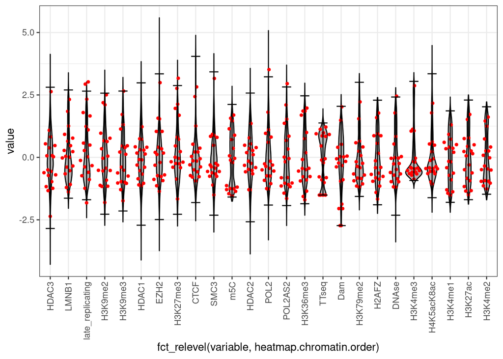

```r
chromatin_features_plot <-  clone5_z.score_chrom_tib %>% reshape2::melt(id.vars = c("pool","ID","binsize"))

##95% CI for each feature
CI99_chromatin_features <- chromatin_features_plot %>% dplyr::group_by(variable) %>% dplyr::summarise(CI0.5 = quantile(value, 0.005), CI99.5 = quantile(value, 0.995), range = CI99.5 - CI0.5, mean = mean(value))

#Plot S7A:  Chromatin ranges
ggplot(chromatin_features_plot) +
  geom_violin(aes(fct_relevel(variable, heatmap.chromatin.order), value), fill = "grey70", color = "black") + theme_bw() +
  theme(axis.text.x = element_text(angle = 90, vjust = 0.5, hjust = 1))+
  geom_quasirandom(data = chromatin_features_plot %>% filter(ID %in% clone5_bc_cluster), aes(fct_relevel(variable, heatmap.chromatin.order), value), color = "red", size = 1)  +
  geom_errorbar(data = CI99_chromatin_features, aes(x = variable,ymin = CI0.5, ymax = CI99.5), color = "black", width = 0.5)
```

A) In grey, distribution of genome-wide chromatin scores, with the two-sided 99% confidence interval (99CI) marked by the horizontal black lines (top 0.5% and bottom 0.5%). In red, chromatin scores of all 19 IPRs in clone 5 for which MMEJ:NHEJ balance was measured in the screen.

# Figure S6B

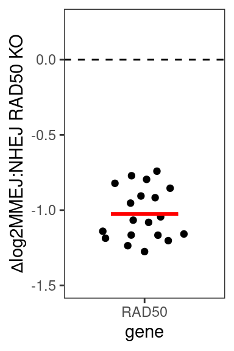

```r
#pdf("/home/x.vergara/XV_P3_ChromDSBScreen/xv_CRISPR_screen_figures/export/xv20220117_paper_figure_short/supplementary_figures/figure_S7_effect_size/xv20231102_RAD50_global_example.pdf",width = 2, height = 3)
ggplot(step2.epistasis %>%
         dplyr::filter(gene %in% c("RAD50")),
       aes(gene, mean.log2foldchange)) +
  geom_quasirandom() +
  stat_summary(geom = "errorbar",fun.min = mean, fun = mean, fun.max = mean, color = "red", size = 1, width = 0.5) +
  theme_bw() + ylab("∆log2MMEJ:NHEJ RAD50 KO") + theme(legend.position = "none") +
  theme(panel.grid = element_blank()) + ylim(c(-1.5,0.25)) +
  geom_hline(yintercept = 0, linetype =2 )
```

```r
#dev.off()
```

2. Example of global ∆log2MMEJ:NHEJ score of RAD50 KO. The global ∆log2MMEJ:NHEJ score (∆Global in short) is the mean ∆log2MMEJ:NHEJ score (in red) of all 19 IPRs (individual datapoints, n = 3).

# Figure S6C

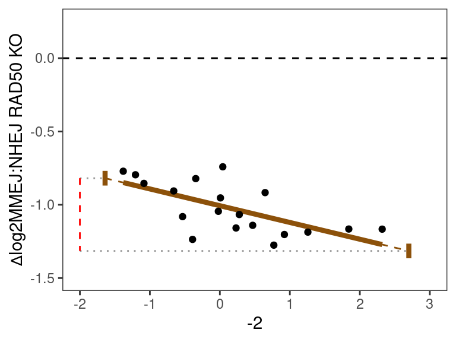

```r
# Plot RAD50 with LMNB1
#pdf("/home/x.vergara/XV_P3_ChromDSBScreen/xv_CRISPR_screen_figures/export/xv20220117_paper_figure_short/supplementary_figures/figure_S7_effect_size/xv20231102_RAD50_global_example_CCD_delta.pdf",width = 4, height = 3)
ggplot() +
  geom_segment(aes(x = -2, xend = 2.7,y = -1.0064 - 0.1143*2.7, yend = -1.0064 - 0.1143*2.7), color = "grey60", linetype = 3) +
  geom_segment(aes(x = -2, xend = -1.64,y = -1.0064 - 0.1143*-1.64, yend = -1.0064 - 0.1143*-1.64), color = "grey60", linetype = 3) +
  geom_segment(aes(x = -2, xend = -2,y = -1.0064 - 0.1143*-1.64, yend = -1.0064 - 0.1143*2.7), color = "red", linetype = 2) +
  geom_segment(aes(x = -1.64, xend = -1.64, y = -1.0064 - 0.1143*-1.64+0.05, yend = -1.0064 - 0.1143*-1.64-0.05),color = "#8c510a", size = 1.5)  +
  geom_segment(aes(x = 2.7, xend = 2.7, y = -1.0064 - 0.1143*2.7+0.05, yend = -1.0064 - 0.1143*2.7-0.05),color = "#8c510a", size = 1.5) +
  geom_segment(aes(x = -1.64, xend = 2.7,y = -1.0064 - 0.1143*-1.64, yend = -1.0064 - 0.1143*2.7),color = "#8c510a", linetype = 2) +

  geom_smooth(data = step2.epistasis %>%
         dplyr::filter(gene %in% c("RAD50")),
       aes(LMNB1,mean.log2foldchange),
       method = "lm", se = F, color = "#8c510a", size = 1.5) +
  geom_point(data = step2.epistasis %>%
         dplyr::filter(gene %in% c("RAD50")),
       aes(LMNB1,mean.log2foldchange)) +
  theme_bw() + ylab("∆log2MMEJ:NHEJ RAD50 KO") + theme(legend.position = "none") +
  theme(panel.grid = element_blank()) + ylim(c(-1.5,0.25)) + xlim(c(-2,3)) + geom_hline(yintercept = 0, linetype =2)
```

```r
#dev.off()
```

3. Example on how the CCD ∆log2MMEJ:NHEJ score (∆CCD in short) is estimated. In this case, the linear fit of ∆log2MMEJ:NHEJ scores with LMNB1 interaction levels (Same as in Fig. 2B). To estimate the genome-wide ∆CCD of RAD50, we extrapolated the linear fit to cover the two-sided 99CI of ge-nome-wide LMNB1 levels (LMNB199CI = [-1.64,2.7]) in brown. The maximum and minimum values of this extrapolated fit are taken as the ∆log2MMEJ:NHEJ estimated in the absence and presence of LMNB1 interactions (0.005 and 0.995 percentiles). The differential between these two values is taken as the ∆CCD of RAD50.

# Figure S6D

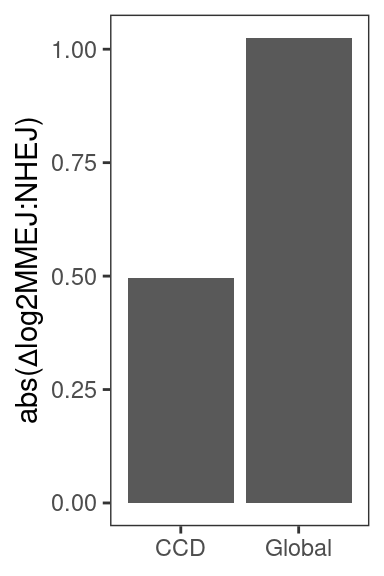

```r
RAD50_example <- tibble(effect = c("CCD","Global"), log2MMEJNHEJ = c(0.4954,1.025))

#Plot
#pdf("/home/x.vergara/XV_P3_ChromDSBScreen/xv_CRISPR_screen_figures/export/xv20220117_paper_figure_short/supplementary_figures/figure_S7_effect_size/xv20231102_RAD50_abs_estimation.pdf",width = 2, height = 3)
ggplot(RAD50_example) +
  geom_col(aes(effect, log2MMEJNHEJ)) +
  theme_bw() +
  theme(panel.grid = element_blank(),
        axis.title.x = element_blank()) +
  ylab("abs(∆log2MMEJ:NHEJ)")
```

```r
#dev.off()
```

4. Direct comparison of CCD and Global ∆log2MMEJ:NHEJ balance of RAD50. To compare between M- and N-synergies, which have different signs, we calculate the absolute CCD and Global ∆og2MMEJ:NHEJ balance.

# Fig. S6E

## Preparatory chunk: Compare CCDs vs. global effect

```r
##Filter max estimated FC
max_estimated_FC_CCD_gene <- table_S3_CCDs %>% dplyr::group_by(gene) %>% dplyr::summarise(max_CCD_estim_diff = max(abs(CCD_estim_diff)))

## Filter max(CCDs)
max_estimated_CCD_FC <- table_S3_CCDs %>% dplyr::select(gene,DR_effect_type,global_diff, CCD_model_p_adj, global_p_adj) %>% distinct() %>% left_join(max_estimated_FC_CCD_gene)
```

## Plot

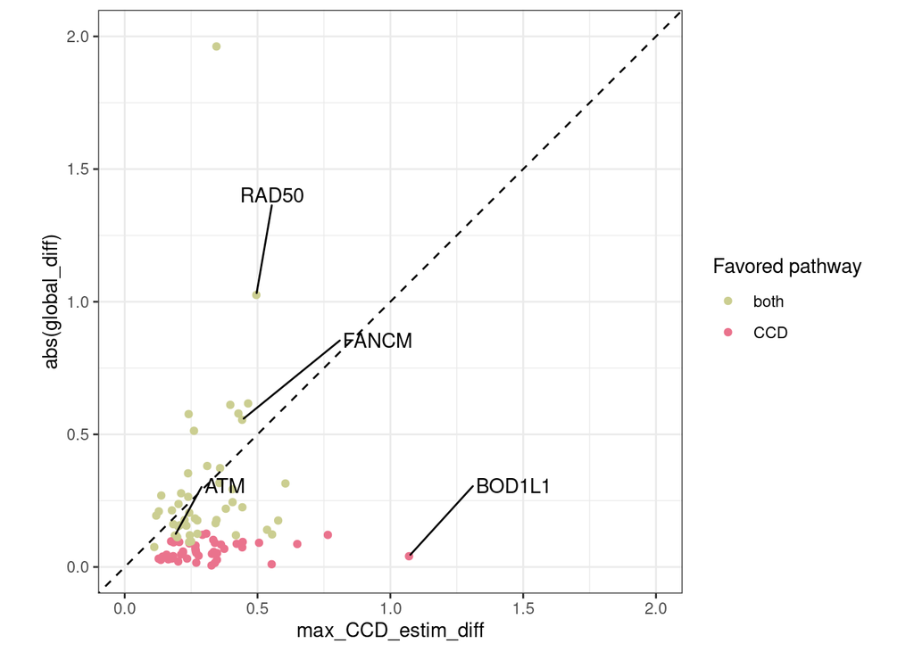

```r
#Highlight proteins
highlight_prots <- c("RAD50","FANCM","BOD1L1", "ATM")

#Plot
ggplot(max_estimated_CCD_FC %>% filter(DR_effect_type %in% c("CCD","both"))) +
  geom_point(aes(max_CCD_estim_diff, abs(global_diff), color = DR_effect_type)) +
  geom_text_repel(data = subset(max_estimated_CCD_FC, gene %in% highlight_prots), aes(max_CCD_estim_diff, abs(global_diff), label = gene), box.padding = 2.5) +
  scale_color_manual(values = c("#CBCE91","#EA738D")) + theme(legend.position = "top") + geom_abline(linetype = 2) + labs(color = "Favored pathway") + theme_bw() + coord_fixed(xlim = c(0,2), ylim = c(0,2))
```